# act_report

## Report: act_report

This report communicates the insights and displays the visualization(s) produced from your wrangled data. It is to be framed as an external document, like a blog post or magazine article.

```python
from IPython import display
```

### Categorization of dog data type is largely indescriptive

Part of the descriptive properties of the dataset includes categorizing the dog type. These categories are `doggo`, `puppo`, `pupper`, `floofer` and `None`

A [link](https://www.tastefullyoffensive.com/2017/07/the-difference-between-doggos-puppers-and-woofers/) explaining the difference between each type is always useful for the generic human being and the cat lovers.

A lot of the entries in the dataset don't have a set dog type label. With approximately 84% of the entries labelled as `None`. This highlights the inefficiency of the labelling mechanism used for this dataset. There are multiple reasons for the supposed erroneous labelling. One day to mitigate this is to perhaps suggest the compulsory categorization of each dog in each tweet.

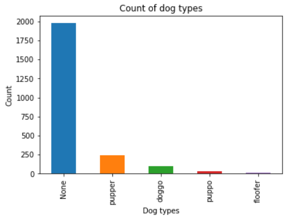

```python
display.Image("./Images/dog_types.png")
```

### Outlier ranges

The denominator rating did not yield as much of an interesting distribution as the numerator, since a significantly large portion of these ratings were primarily out of 10.

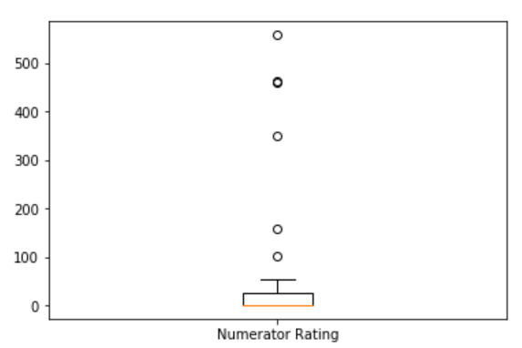

```python
display.Image("./Images/box_whisker.png")
```

### Insight 3: Tweet traffic

For the aggregated period, it seems the most traffic for the site comes through the last months of the year and January. This can point to multiple causes but one to consider is that these are typically festive months. A more interesting analysis would be to also consider the years when applying the filter.

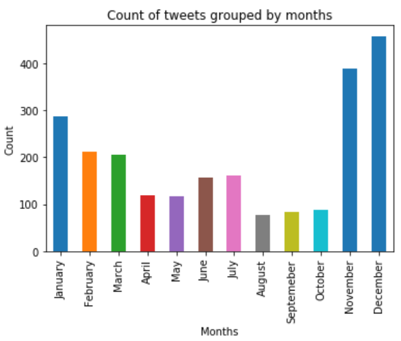

```python
display.Image("./Images/group_by_month.png")
```